# Factors Affecting Loan Status outcome

## Investigation Overview

In this investigation, I wanted to look at the factors influencing Loan Status outcome and what factors could predict their outcome. The main focus was on BorrowerRate,BorrowerAPR, Loan term, and ProsperScore.

## Dataset Overview

The data consisted of loan's status and attributes of 113,937 loans with 81 variables involved. The attributes included BorrowerRate,BorrowerAPR, Loan term, and ProsperScore; as well as additional atrtributes such as ListingKey, ListingNumber, ListingCreationDate, CreditGrade amongst several others. LoanStatus, ListingCategory, and ProsperRating (Alpha)w were converteed into ordered categorical types.

## Variation of Loan Status

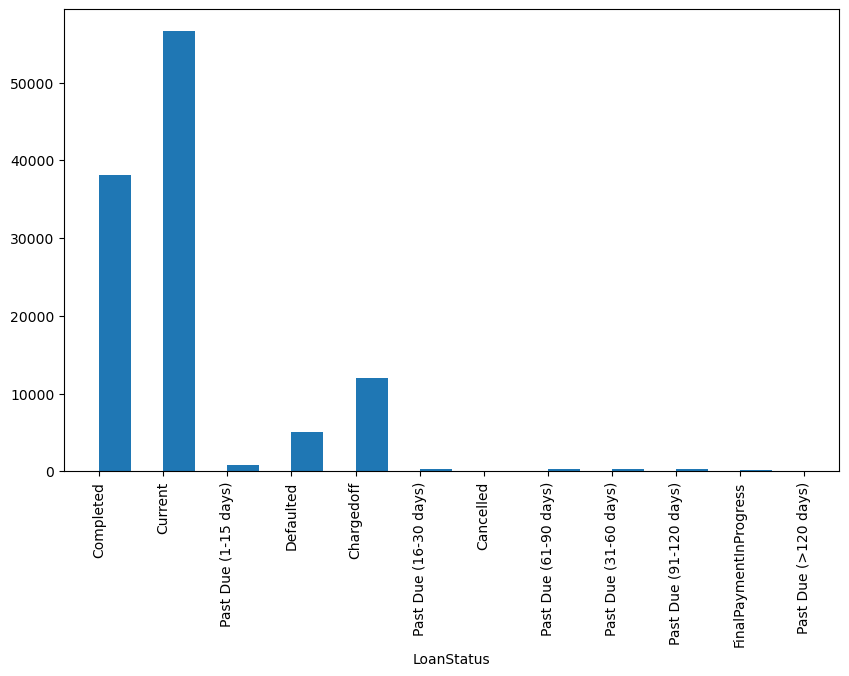

## Distribution of BorrowerRate

BorrowerRate refers to the Borrower's interest rate for a loan. The most rates attached to loansapproximately range from 0.1 to 0.3

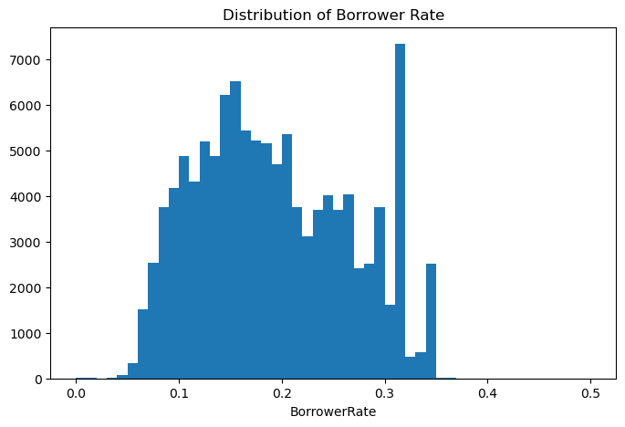

## BorrowerRate vs Loan Status

Plotting BorrowerRate vs Loan status on a violin plot, We see that the overall shape and distribution of the tips are similar for loans with loan status past due. The loans with 'outliers' or abnormally high values values(though a very small proportion) are those marked Completed, chargedoff or defaulted. This tells us that those with really high BorrowerRates either complete their loans, are charged off or defaulted.

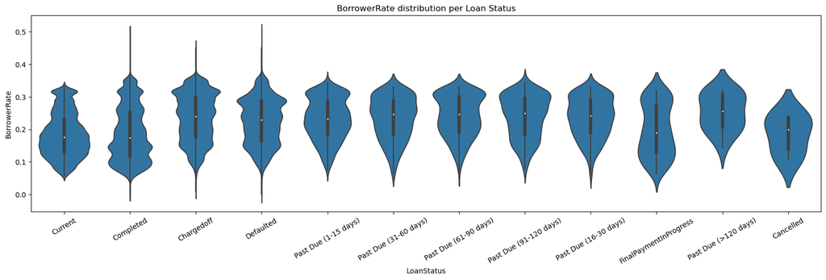

### Loan Status and Terms, on BorrowerRate vs BorrowerAPR

There is an interaction effect visible between Loan Status, Terms, BorrowerRate and BorrowerAPR. This is most evident for the 'Term' measure with value 36(i.e 36 months). As BorrowerRate increases , you can observe an increase in BorrowerAPR. At the same time, you can see an increase in the 'cloud of points' across the plots with loan status : complete, defaulted and chargedoff. This accounts for the base observation that those with really high BorrowerRates either complete their loans, are charged off or defaulted.

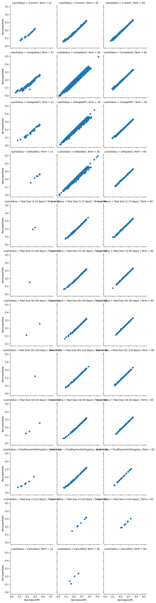

[output not shown]